# Computational Statistics - CS601C Final Project

- The linear regression plot shows that there is a positive linear relationship between ‘Users’ and ‘Cost.P.M’, which means that as the number of users increases, the monthly cost also increases the Data points is well scattered along the regression line , indicating variability and indicating that While the number of users is an important determinant of spending, there are obviously other factors that affect spending as well.

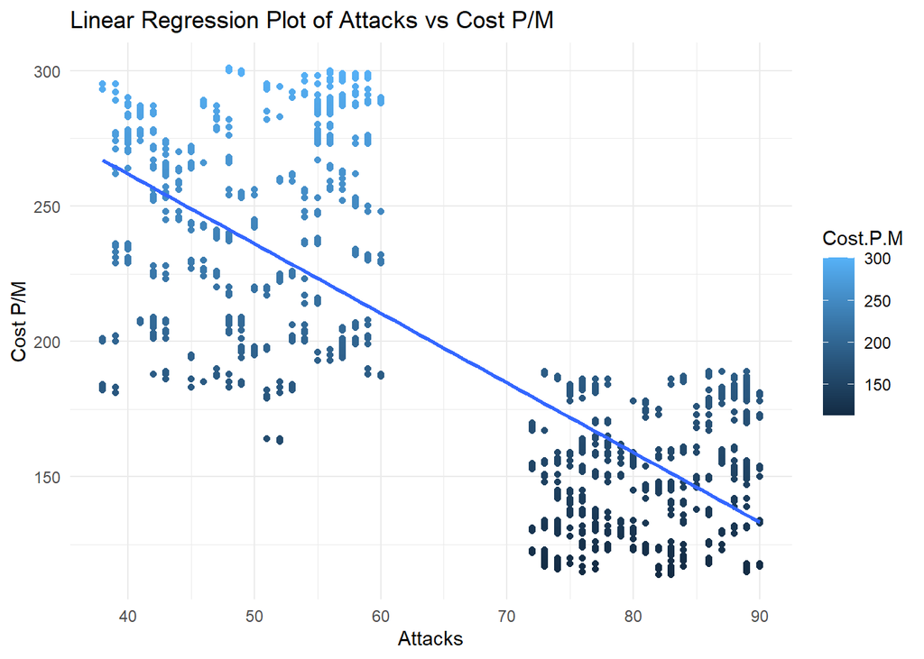

```r
# Utilized ggplot2 to create a scatter plot with a linear regression line.
# Plots 'Attacks' against 'Cost P/M' from the 'Cybercost' dataset.
# Points on the plot are colored based on the 'Cost P/M' values.
# 'geom_point()' adds the scatter plot points.
# 'geom_smooth()' applies a linear regression line without confidence intervals (se = FALSE).
# 'labs()' sets the plot's title and axis labels, focusing on Attacks versus Cost P/M.
# 'theme_minimal()' is used to apply a minimalistic and clean theme to the plot.

ggplot(Cybercost, aes(x = Attacks, y = `Cost.P.M`, color = Cost.P.M)) +
  geom_point() +
  geom_smooth(method = "lm", se = FALSE) +
  labs(title = "Linear Regression Plot of Attacks vs Cost P/M", x = "Attacks", y = "Cost P/M") +
  theme_minimal()
```

**Findings**

- The linear regression plot for ‘Attacks’ vs ‘Cost P/M’ indicates a negative correlation, suggesting that as the number of attacks increases, the cost per month tends to decrease. This could imply that systems experiencing more attacks might have better cost efficiencies, possibly due to economies of scale in cybersecurity measures, or it could reflect reporting or data collection anomalies.
- The data points are dispersed, indicating other factors may also play a significant role in influencing the cost.
5. Now comes the interesting part of the study. Your job is determining how is cost P/M determined. You are to use all your skills that you have learned during this course to determine what attribute(s) are best. Note: one variable (attribute) may not be enough to determine how the cost is determined.

5.1. Correlation Analysis

Analyzing the correlation between “Cost P/M” and other attributes. This can assist in determining the variables that could have a significant correlation with our desired outcome.

```r
correlation_matrix <- cor(Cybercost)
correlation_with_cost <- correlation_matrix["Cost.P.M", ]
```

5.2. Visual Exploration

Utilizing scatter plots and other visualizations to explore relationships between “Cost P/M” and other attributes. This can help identify trends, patterns, and outliers.

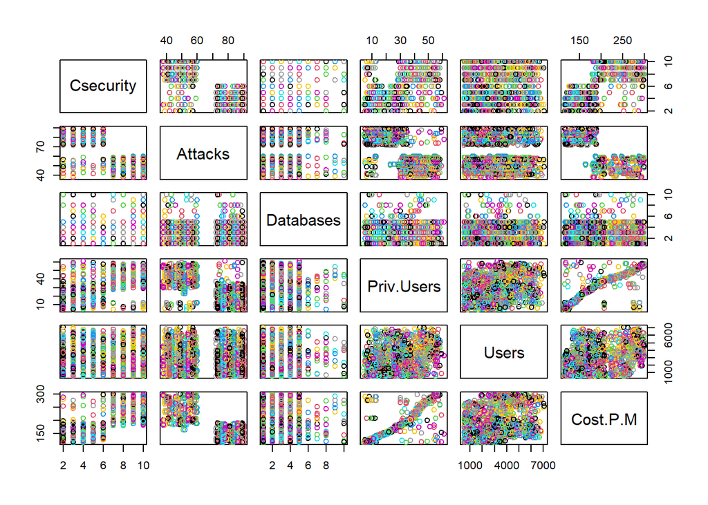

```r
library(ggplot2)
pairs(Cybercost, col = as.numeric(grouping_variable))  # For an overall view
```

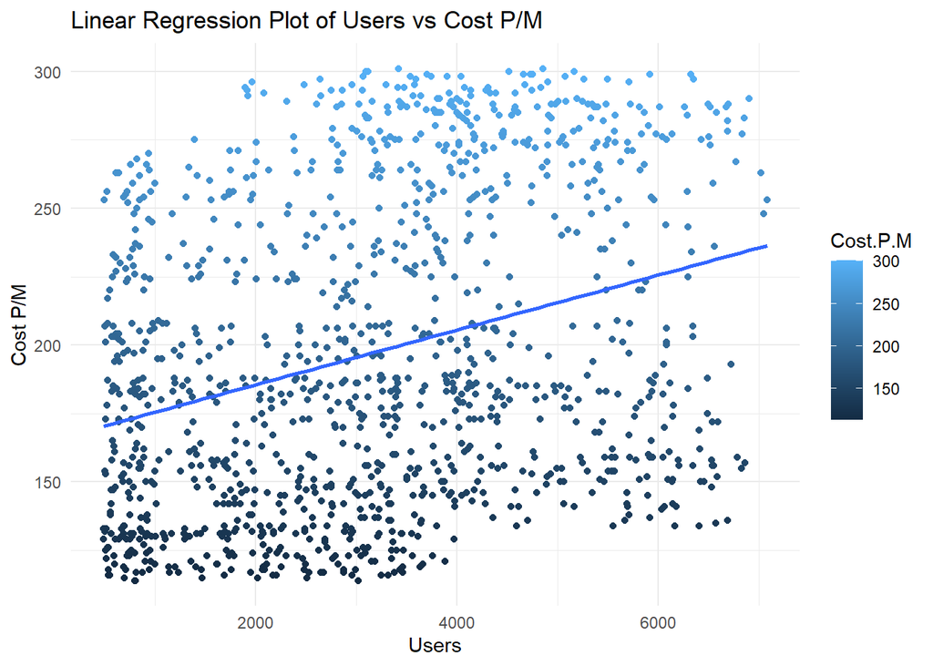

```r
ggplot(Cybercost, aes(x = Users, y = `Cost.P.M`, color = `Cost.P.M`)) +
  geom_point() +
  geom_smooth(method = "lm", se = FALSE) +  # Linear model line without standard error
  labs(title = "Linear Regression Plot of Users vs Cost P/M", x = "Users", y = "Cost P/M") +
  theme_minimal()
```

**Findings**